# Risk Factor Analysis

## Outcome Variable

**Outcome Variable:** ever_sstunted

## Predictor Variables

**Intervention Variable:** single

**Adjustment Set:**

unadjusted

## Stratifying Variables

The analysis was stratified on these variable(s):

- agecat
- studyid
- country

## Data Summary

| agecat | studyid | country | single | ever_sstunted | n_cell | n |
| --- | --- | --- | --- | --- | --- | --- |
| 0-24 months | COHORTS | GUATEMALA | 0 | 0 | 582 | 1207 |
| 0-24 months | COHORTS | GUATEMALA | 0 | 1 | 527 | 1207 |
| 0-24 months | COHORTS | GUATEMALA | 1 | 0 | 43 | 1207 |
| 0-24 months | COHORTS | GUATEMALA | 1 | 1 | 55 | 1207 |
| 0-24 months | COHORTS | INDIA | 0 | 0 | 4639 | 5384 |
| 0-24 months | COHORTS | INDIA | 0 | 1 | 736 | 5384 |
| 0-24 months | COHORTS | INDIA | 1 | 0 | 7 | 5384 |
| 0-24 months | COHORTS | INDIA | 1 | 1 | 2 | 5384 |
| 0-24 months | COHORTS | PHILIPPINES | 0 | 0 | 1889 | 3018 |
| 0-24 months | COHORTS | PHILIPPINES | 0 | 1 | 1054 | 3018 |
| 0-24 months | COHORTS | PHILIPPINES | 1 | 0 | 50 | 3018 |
| 0-24 months | COHORTS | PHILIPPINES | 1 | 1 | 25 | 3018 |
| 0-24 months | Guatemala BSC | GUATEMALA | 0 | 0 | 207 | 282 |
| 0-24 months | Guatemala BSC | GUATEMALA | 0 | 1 | 45 | 282 |
| 0-24 months | Guatemala BSC | GUATEMALA | 1 | 0 | 22 | 282 |
| 0-24 months | Guatemala BSC | GUATEMALA | 1 | 1 | 8 | 282 |
| 0-24 months | MAL-ED | BANGLADESH | 0 | 0 | 207 | 265 |
| 0-24 months | MAL-ED | BANGLADESH | 0 | 1 | 58 | 265 |
| 0-24 months | MAL-ED | BANGLADESH | 1 | 0 | 0 | 265 |
| 0-24 months | MAL-ED | BANGLADESH | 1 | 1 | 0 | 265 |
| 0-24 months | MAL-ED | BRAZIL | 0 | 0 | 183 | 233 |
| 0-24 months | MAL-ED | BRAZIL | 0 | 1 | 14 | 233 |
| 0-24 months | MAL-ED | BRAZIL | 1 | 0 | 28 | 233 |
| 0-24 months | MAL-ED | BRAZIL | 1 | 1 | 8 | 233 |
| 0-24 months | MAL-ED | INDIA | 0 | 0 | 192 | 249 |
| 0-24 months | MAL-ED | INDIA | 0 | 1 | 57 | 249 |
| 0-24 months | MAL-ED | INDIA | 1 | 0 | 0 | 249 |
| 0-24 months | MAL-ED | INDIA | 1 | 1 | 0 | 249 |
| 0-24 months | MAL-ED | NEPAL | 0 | 0 | 219 | 240 |
| 0-24 months | MAL-ED | NEPAL | 0 | 1 | 21 | 240 |

[output cut: 82 more lines]

The following strata were considered:

- agecat: 0-24 months, studyid: COHORTS, country: GUATEMALA
- agecat: 0-24 months, studyid: COHORTS, country: INDIA
- agecat: 0-24 months, studyid: COHORTS, country: PHILIPPINES
- agecat: 0-24 months, studyid: Guatemala BSC, country: GUATEMALA
- agecat: 0-24 months, studyid: MAL-ED, country: BANGLADESH
- agecat: 0-24 months, studyid: MAL-ED, country: BRAZIL
- agecat: 0-24 months, studyid: MAL-ED, country: INDIA
- agecat: 0-24 months, studyid: MAL-ED, country: NEPAL
- agecat: 0-24 months, studyid: MAL-ED, country: PERU
- agecat: 0-24 months, studyid: MAL-ED, country: SOUTH AFRICA
- agecat: 0-24 months, studyid: MAL-ED, country: TANZANIA, UNITED REPUBLIC OF
- agecat: 0-24 months, studyid: PROBIT, country: BELARUS
- agecat: 0-24 months, studyid: TanzaniaChild2, country: TANZANIA, UNITED REPUBLIC OF
- agecat: 0-24 months, studyid: ZVITAMBO, country: ZIMBABWE
- agecat: 0-6 months, studyid: COHORTS, country: GUATEMALA
- agecat: 0-6 months, studyid: COHORTS, country: INDIA
- agecat: 0-6 months, studyid: COHORTS, country: PHILIPPINES
- agecat: 0-6 months, studyid: Guatemala BSC, country: GUATEMALA
- agecat: 0-6 months, studyid: MAL-ED, country: BANGLADESH
- agecat: 0-6 months, studyid: MAL-ED, country: BRAZIL
- agecat: 0-6 months, studyid: MAL-ED, country: INDIA
- agecat: 0-6 months, studyid: MAL-ED, country: NEPAL
- agecat: 0-6 months, studyid: MAL-ED, country: PERU
- agecat: 0-6 months, studyid: MAL-ED, country: SOUTH AFRICA
- agecat: 0-6 months, studyid: MAL-ED, country: TANZANIA, UNITED REPUBLIC OF
- agecat: 0-6 months, studyid: PROBIT, country: BELARUS
- agecat: 0-6 months, studyid: TanzaniaChild2, country: TANZANIA, UNITED REPUBLIC OF
- agecat: 0-6 months, studyid: ZVITAMBO, country: ZIMBABWE

### Dropped Strata

Some strata were dropped due to rare outcomes:

- agecat: 0-24 months, studyid: COHORTS, country: INDIA
- agecat: 0-24 months, studyid: MAL-ED, country: BANGLADESH
- agecat: 0-24 months, studyid: MAL-ED, country: INDIA
- agecat: 0-24 months, studyid: MAL-ED, country: NEPAL
- agecat: 0-24 months, studyid: MAL-ED, country: TANZANIA, UNITED REPUBLIC OF
- agecat: 0-6 months, studyid: COHORTS, country: INDIA
- agecat: 0-6 months, studyid: MAL-ED, country: BANGLADESH
- agecat: 0-6 months, studyid: MAL-ED, country: INDIA
- agecat: 0-6 months, studyid: MAL-ED, country: NEPAL
- agecat: 0-6 months, studyid: MAL-ED, country: TANZANIA, UNITED REPUBLIC OF

## Methods Detail

We’re interested in the causal parameters $E[Y_a]$ for all values of $a \in \mathcal{A}$. These parameters represent the mean outcome if, possibly contrary to fact, we intervened to set all units to have $A=a$. Under the randomization and positivity assumptions, these are identified by the statistical parameters $\psi_a=E_W[E_{Y|A,W}(Y|A=a,W)]$. In addition, we’re interested in the mean of $Y$, $E[Y]$ under no intervention (the observed mean). We will estimate these parameters by using SuperLearner to fit the relevant likelihood factors – $E_{Y|A,W}(Y|A=a,W)$ and $p(A=a|W)$, and then updating our likelihood fit using a joint TMLE.

For unadjusted analyses ($W=\{\}$), initial likelihoods were estimated using Lrnr_glm to estimate the simple $E(Y|A)$ and Lrnr_mean to estimate $p(A)$. For adjusted analyses, a small library containing Lrnr_glmnet, Lrnr_xgboost, and Lrnr_mean was used.

Having estimated these parameters, we will then use the delta method to estimate relative risks and attributable risks relative to a prespecified baseline level of $A$.

# Results Detail

## Results Plots

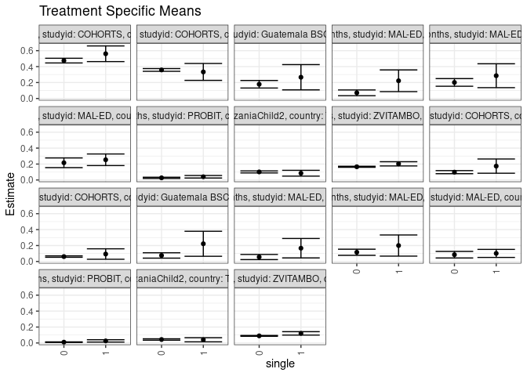

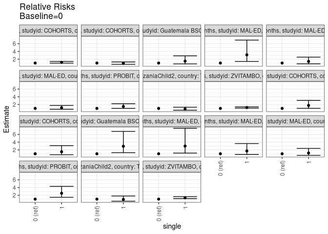

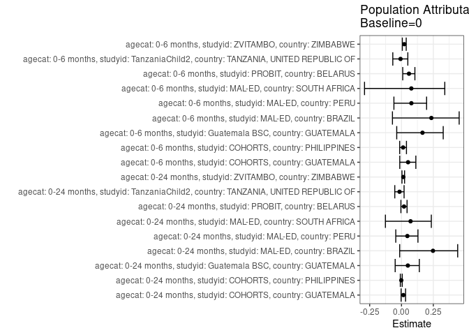

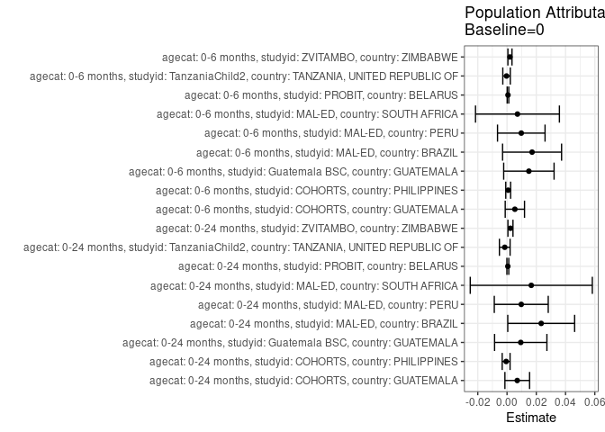

## Results Table

### Parameter: TSM

| agecat | studyid | country | intervention_level | baseline_level | estimate | ci_lower | ci_upper |
| --- | --- | --- | --- | --- | --- | --- | --- |
| 0-24 months | COHORTS | GUATEMALA | 0 | NA | 0.4752029 | 0.4457995 | 0.5046063 |
| 0-24 months | COHORTS | GUATEMALA | 1 | NA | 0.5612245 | 0.4629356 | 0.6595134 |
| 0-24 months | COHORTS | PHILIPPINES | 0 | NA | 0.3581380 | 0.3408104 | 0.3754655 |
| 0-24 months | COHORTS | PHILIPPINES | 1 | NA | 0.3333333 | 0.2272651 | 0.4394015 |
| 0-24 months | Guatemala BSC | GUATEMALA | 0 | NA | 0.1785714 | 0.1312007 | 0.2259422 |
| 0-24 months | Guatemala BSC | GUATEMALA | 1 | NA | 0.2666667 | 0.1081431 | 0.4251903 |
| 0-24 months | MAL-ED | BRAZIL | 0 | NA | 0.0710660 | 0.0351099 | 0.1070221 |
| 0-24 months | MAL-ED | BRAZIL | 1 | NA | 0.2222222 | 0.0861240 | 0.3583204 |
| 0-24 months | MAL-ED | PERU | 0 | NA | 0.2014925 | 0.1533901 | 0.2495950 |
| 0-24 months | MAL-ED | PERU | 1 | NA | 0.2857143 | 0.1358032 | 0.4356254 |
| 0-24 months | MAL-ED | SOUTH AFRICA | 0 | NA | 0.2159091 | 0.1550251 | 0.2767931 |
| 0-24 months | MAL-ED | SOUTH AFRICA | 1 | NA | 0.2536232 | 0.1809164 | 0.3263299 |
| 0-24 months | PROBIT | BELARUS | 0 | NA | 0.0270921 | 0.0195793 | 0.0346049 |
| 0-24 months | PROBIT | BELARUS | 1 | NA | 0.0404040 | 0.0246121 | 0.0561960 |
| 0-24 months | TanzaniaChild2 | TANZANIA, UNITED REPUBLIC OF | 0 | NA | 0.1013482 | 0.0885920 | 0.1141045 |
| 0-24 months | TanzaniaChild2 | TANZANIA, UNITED REPUBLIC OF | 1 | NA | 0.0848214 | 0.0483274 | 0.1213154 |
| 0-24 months | ZVITAMBO | ZIMBABWE | 0 | NA | 0.1656890 | 0.1593285 | 0.1720495 |
| 0-24 months | ZVITAMBO | ZIMBABWE | 1 | NA | 0.2024747 | 0.1760585 | 0.2288909 |
| 0-6 months | COHORTS | GUATEMALA | 0 | NA | 0.0983425 | 0.0789320 | 0.1177531 |
| 0-6 months | COHORTS | GUATEMALA | 1 | NA | 0.1739130 | 0.0844331 | 0.2633930 |
| 0-6 months | COHORTS | PHILIPPINES | 0 | NA | 0.0615019 | 0.0528192 | 0.0701845 |
| 0-6 months | COHORTS | PHILIPPINES | 1 | NA | 0.0933333 | 0.0278797 | 0.1587870 |
| 0-6 months | Guatemala BSC | GUATEMALA | 0 | NA | 0.0756303 | 0.0419751 | 0.1092854 |
| 0-6 months | Guatemala BSC | GUATEMALA | 1 | NA | 0.2222222 | 0.0651105 | 0.3793340 |
| 0-6 months | MAL-ED | BRAZIL | 0 | NA | 0.0558376 | 0.0237057 | 0.0879694 |
| 0-6 months | MAL-ED | BRAZIL | 1 | NA | 0.1666667 | 0.0446653 | 0.2886680 |
| 0-6 months | MAL-ED | PERU | 0 | NA | 0.1156716 | 0.0773169 | 0.1540264 |
| 0-6 months | MAL-ED | PERU | 1 | NA | 0.2000000 | 0.0672630 | 0.3327370 |
| 0-6 months | MAL-ED | SOUTH AFRICA | 0 | NA | 0.0852273 | 0.0439101 | 0.1265444 |
| 0-6 months | MAL-ED | SOUTH AFRICA | 1 | NA | 0.1014493 | 0.0509951 | 0.1519034 |
| 0-6 months | PROBIT | BELARUS | 0 | NA | 0.0103093 | 0.0068864 | 0.0137322 |
| 0-6 months | PROBIT | BELARUS | 1 | NA | 0.0259740 | 0.0114705 | 0.0404775 |
| 0-6 months | TanzaniaChild2 | TANZANIA, UNITED REPUBLIC OF | 0 | NA | 0.0437006 | 0.0350597 | 0.0523415 |
| 0-6 months | TanzaniaChild2 | TANZANIA, UNITED REPUBLIC OF | 1 | NA | 0.0401786 | 0.0144564 | 0.0659008 |
| 0-6 months | ZVITAMBO | ZIMBABWE | 0 | NA | 0.0892312 | 0.0843516 | 0.0941109 |
| 0-6 months | ZVITAMBO | ZIMBABWE | 1 | NA | 0.1206313 | 0.0991966 | 0.1420660 |

### Parameter: E(Y)

| agecat | studyid | country | intervention_level | baseline_level | estimate | ci_lower | ci_upper |
| --- | --- | --- | --- | --- | --- | --- | --- |
| 0-24 months | COHORTS | GUATEMALA | NA | NA | 0.4821872 | 0.4539860 | 0.5103885 |
| 0-24 months | COHORTS | PHILIPPINES | NA | NA | 0.3575215 | 0.3404198 | 0.3746233 |
| 0-24 months | Guatemala BSC | GUATEMALA | NA | NA | 0.1879433 | 0.1422658 | 0.2336207 |
| 0-24 months | MAL-ED | BRAZIL | NA | NA | 0.0944206 | 0.0567935 | 0.1320477 |
| 0-24 months | MAL-ED | PERU | NA | NA | 0.2112211 | 0.1651858 | 0.2572564 |
| 0-24 months | MAL-ED | SOUTH AFRICA | NA | NA | 0.2324841 | 0.1856873 | 0.2792809 |
| 0-24 months | PROBIT | BELARUS | NA | NA | 0.0276380 | 0.0201988 | 0.0350773 |
| 0-24 months | TanzaniaChild2 | TANZANIA, UNITED REPUBLIC OF | NA | NA | 0.0997895 | 0.0877329 | 0.1118460 |
| 0-24 months | ZVITAMBO | ZIMBABWE | NA | NA | 0.1680223 | 0.1618323 | 0.1742123 |
| 0-6 months | COHORTS | GUATEMALA | NA | NA | 0.1036961 | 0.0845403 | 0.1228519 |
| 0-6 months | COHORTS | PHILIPPINES | NA | NA | 0.0622929 | 0.0536688 | 0.0709170 |
| 0-6 months | Guatemala BSC | GUATEMALA | NA | NA | 0.0905660 | 0.0559470 | 0.1251850 |
| 0-6 months | MAL-ED | BRAZIL | NA | NA | 0.0729614 | 0.0394957 | 0.1064270 |
| 0-6 months | MAL-ED | PERU | NA | NA | 0.1254125 | 0.0880603 | 0.1627648 |
| 0-6 months | MAL-ED | SOUTH AFRICA | NA | NA | 0.0923567 | 0.0602816 | 0.1244318 |
| 0-6 months | PROBIT | BELARUS | NA | NA | 0.0109519 | 0.0074064 | 0.0144975 |
| 0-6 months | TanzaniaChild2 | TANZANIA, UNITED REPUBLIC OF | NA | NA | 0.0433684 | 0.0351750 | 0.0515619 |
| 0-6 months | ZVITAMBO | ZIMBABWE | NA | NA | 0.0912208 | 0.0864511 | 0.0959905 |

### Parameter: RR

| agecat | studyid | country | intervention_level | baseline_level | estimate | ci_lower | ci_upper |
| --- | --- | --- | --- | --- | --- | --- | --- |
| 0-24 months | COHORTS | GUATEMALA | 0 | 0 | 1.0000000 | 1.0000000 | 1.000000 |
| 0-24 months | COHORTS | GUATEMALA | 1 | 0 | 1.1810208 | 0.9808233 | 1.422081 |
| 0-24 months | COHORTS | PHILIPPINES | 0 | 0 | 1.0000000 | 1.0000000 | 1.000000 |
| 0-24 months | COHORTS | PHILIPPINES | 1 | 0 | 0.9307400 | 0.6745988 | 1.284137 |
| 0-24 months | Guatemala BSC | GUATEMALA | 0 | 0 | 1.0000000 | 1.0000000 | 1.000000 |
| 0-24 months | Guatemala BSC | GUATEMALA | 1 | 0 | 1.4933333 | 0.7788347 | 2.863309 |
| 0-24 months | MAL-ED | BRAZIL | 0 | 0 | 1.0000000 | 1.0000000 | 1.000000 |
| 0-24 months | MAL-ED | BRAZIL | 1 | 0 | 3.1269841 | 1.4129327 | 6.920379 |
| 0-24 months | MAL-ED | PERU | 0 | 0 | 1.0000000 | 1.0000000 | 1.000000 |
| 0-24 months | MAL-ED | PERU | 1 | 0 | 1.4179894 | 0.7967560 | 2.523601 |
| 0-24 months | MAL-ED | SOUTH AFRICA | 0 | 0 | 1.0000000 | 1.0000000 | 1.000000 |
| 0-24 months | MAL-ED | SOUTH AFRICA | 1 | 0 | 1.1746758 | 0.7857428 | 1.756126 |
| 0-24 months | PROBIT | BELARUS | 0 | 0 | 1.0000000 | 1.0000000 | 1.000000 |
| 0-24 months | PROBIT | BELARUS | 1 | 0 | 1.4913601 | 1.0044969 | 2.214198 |
| 0-24 months | TanzaniaChild2 | TANZANIA, UNITED REPUBLIC OF | 0 | 0 | 1.0000000 | 1.0000000 | 1.000000 |
| 0-24 months | TanzaniaChild2 | TANZANIA, UNITED REPUBLIC OF | 1 | 0 | 0.8369307 | 0.5345706 | 1.310310 |
| 0-24 months | ZVITAMBO | ZIMBABWE | 0 | 0 | 1.0000000 | 1.0000000 | 1.000000 |
| 0-24 months | ZVITAMBO | ZIMBABWE | 1 | 0 | 1.2220162 | 1.0666310 | 1.400038 |
| 0-6 months | COHORTS | GUATEMALA | 0 | 0 | 1.0000000 | 1.0000000 | 1.000000 |
| 0-6 months | COHORTS | GUATEMALA | 1 | 0 | 1.7684416 | 1.0192112 | 3.068437 |
| 0-6 months | COHORTS | PHILIPPINES | 0 | 0 | 1.0000000 | 1.0000000 | 1.000000 |
| 0-6 months | COHORTS | PHILIPPINES | 1 | 0 | 1.5175691 | 0.7421172 | 3.103305 |
| 0-6 months | Guatemala BSC | GUATEMALA | 0 | 0 | 1.0000000 | 1.0000000 | 1.000000 |
| 0-6 months | Guatemala BSC | GUATEMALA | 1 | 0 | 2.9382716 | 1.2743457 | 6.774802 |
| 0-6 months | MAL-ED | BRAZIL | 0 | 0 | 1.0000000 | 1.0000000 | 1.000000 |
| 0-6 months | MAL-ED | BRAZIL | 1 | 0 | 2.9848485 | 1.1763672 | 7.573588 |
| 0-6 months | MAL-ED | PERU | 0 | 0 | 1.0000000 | 1.0000000 | 1.000000 |
| 0-6 months | MAL-ED | PERU | 1 | 0 | 1.7290323 | 0.8233744 | 3.630854 |
| 0-6 months | MAL-ED | SOUTH AFRICA | 0 | 0 | 1.0000000 | 1.0000000 | 1.000000 |
| 0-6 months | MAL-ED | SOUTH AFRICA | 1 | 0 | 1.1903382 | 0.5943516 | 2.383951 |
| 0-6 months | PROBIT | BELARUS | 0 | 0 | 1.0000000 | 1.0000000 | 1.000000 |
| 0-6 months | PROBIT | BELARUS | 1 | 0 | 2.5194805 | 1.4804517 | 4.287733 |
| 0-6 months | TanzaniaChild2 | TANZANIA, UNITED REPUBLIC OF | 0 | 0 | 1.0000000 | 1.0000000 | 1.000000 |
| 0-6 months | TanzaniaChild2 | TANZANIA, UNITED REPUBLIC OF | 1 | 0 | 0.9194054 | 0.4704504 | 1.796802 |
| 0-6 months | ZVITAMBO | ZIMBABWE | 0 | 0 | 1.0000000 | 1.0000000 | 1.000000 |
| 0-6 months | ZVITAMBO | ZIMBABWE | 1 | 0 | 1.3518959 | 1.1225417 | 1.628111 |

### Parameter: PAR

| agecat | studyid | country | intervention_level | baseline_level | estimate | ci_lower | ci_upper |
| --- | --- | --- | --- | --- | --- | --- | --- |
| 0-24 months | COHORTS | GUATEMALA | 0 | NA | 0.0069844 | -0.0014503 | 0.0154191 |
| 0-24 months | COHORTS | PHILIPPINES | 0 | NA | -0.0006164 | -0.0033068 | 0.0020740 |
| 0-24 months | Guatemala BSC | GUATEMALA | 0 | NA | 0.0093718 | -0.0085135 | 0.0272571 |
| 0-24 months | MAL-ED | BRAZIL | 0 | NA | 0.0233546 | 0.0004972 | 0.0462121 |
| 0-24 months | MAL-ED | PERU | 0 | NA | 0.0097286 | -0.0087092 | 0.0281664 |
| 0-24 months | MAL-ED | SOUTH AFRICA | 0 | NA | 0.0165750 | -0.0251544 | 0.0583044 |
| 0-24 months | PROBIT | BELARUS | 0 | NA | 0.0005460 | -0.0000956 | 0.0011875 |
| 0-24 months | TanzaniaChild2 | TANZANIA, UNITED REPUBLIC OF | 0 | NA | -0.0015587 | -0.0052101 | 0.0020926 |
| 0-24 months | ZVITAMBO | ZIMBABWE | 0 | NA | 0.0023332 | 0.0006034 | 0.0040630 |
| 0-6 months | COHORTS | GUATEMALA | 0 | NA | 0.0053536 | -0.0012462 | 0.0119533 |
| 0-6 months | COHORTS | PHILIPPINES | 0 | NA | 0.0007910 | -0.0008691 | 0.0024512 |
| 0-6 months | Guatemala BSC | GUATEMALA | 0 | NA | 0.0149358 | -0.0022867 | 0.0321583 |
| 0-6 months | MAL-ED | BRAZIL | 0 | NA | 0.0171238 | -0.0030390 | 0.0372866 |
| 0-6 months | MAL-ED | PERU | 0 | NA | 0.0097409 | -0.0065060 | 0.0259878 |
| 0-6 months | MAL-ED | SOUTH AFRICA | 0 | NA | 0.0071294 | -0.0215449 | 0.0358038 |
| 0-6 months | PROBIT | BELARUS | 0 | NA | 0.0006427 | 0.0000965 | 0.0011888 |
| 0-6 months | TanzaniaChild2 | TANZANIA, UNITED REPUBLIC OF | 0 | NA | -0.0003322 | -0.0028918 | 0.0022274 |
| 0-6 months | ZVITAMBO | ZIMBABWE | 0 | NA | 0.0019896 | 0.0005909 | 0.0033882 |

### Parameter: PAF

| agecat | studyid | country | intervention_level | baseline_level | estimate | ci_lower | ci_upper |
| --- | --- | --- | --- | --- | --- | --- | --- |
| 0-24 months | COHORTS | GUATEMALA | 0 | NA | 0.0144847 | -0.0031815 | 0.0318398 |
| 0-24 months | COHORTS | PHILIPPINES | 0 | NA | -0.0017241 | -0.0092775 | 0.0057727 |
| 0-24 months | Guatemala BSC | GUATEMALA | 0 | NA | 0.0498652 | -0.0497480 | 0.1400259 |
| 0-24 months | MAL-ED | BRAZIL | 0 | NA | 0.2473466 | -0.0142644 | 0.4414798 |
| 0-24 months | MAL-ED | PERU | 0 | NA | 0.0460588 | -0.0450413 | 0.1292173 |
| 0-24 months | MAL-ED | SOUTH AFRICA | 0 | NA | 0.0712951 | -0.1264129 | 0.2343015 |
| 0-24 months | PROBIT | BELARUS | 0 | NA | 0.0197542 | -0.0047297 | 0.0436414 |
| 0-24 months | TanzaniaChild2 | TANZANIA, UNITED REPUBLIC OF | 0 | NA | -0.0156202 | -0.0528387 | 0.0202825 |
| 0-24 months | ZVITAMBO | ZIMBABWE | 0 | NA | 0.0138864 | 0.0035453 | 0.0241202 |
| 0-6 months | COHORTS | GUATEMALA | 0 | NA | 0.0516274 | -0.0136032 | 0.1126600 |
| 0-6 months | COHORTS | PHILIPPINES | 0 | NA | 0.0126987 | -0.0142640 | 0.0389447 |
| 0-6 months | Guatemala BSC | GUATEMALA | 0 | NA | 0.1649160 | -0.0375013 | 0.3278415 |
| 0-6 months | MAL-ED | BRAZIL | 0 | NA | 0.2346969 | -0.0710660 | 0.4531721 |
| 0-6 months | MAL-ED | PERU | 0 | NA | 0.0776709 | -0.0596587 | 0.1972028 |
| 0-6 months | MAL-ED | SOUTH AFRICA | 0 | NA | 0.0771944 | -0.2905761 | 0.3401627 |
| 0-6 months | PROBIT | BELARUS | 0 | NA | 0.0586793 | 0.0096570 | 0.1052750 |
| 0-6 months | TanzaniaChild2 | TANZANIA, UNITED REPUBLIC OF | 0 | NA | -0.0076596 | -0.0684244 | 0.0496494 |
| 0-6 months | ZVITAMBO | ZIMBABWE | 0 | NA | 0.0218104 | 0.0063918 | 0.0369897 |